# TP Extra

MenaDT

2023-02-14

#Reexplorando PROPERATI

##Este notebook En este notebook el objetivo es que ustedes puedan emplear lo visto en el notebook Nociones básicas de estadística descriptiva para caracterizar y repensar el dataset de propiedades de ar_properties.csv.

Proponemos una serie de preguntas guía a responder usando las herramientas presentadas en el notebook de estadística descriptiva. En todas la preguntas propuestas, el objetivo es que identifiquen alguna medida o visualización que les ayude a responder la pregunta conceptual realizada. Esto significa que todo gráfico o número debería ir acompañado de una interpretación del significado que ustedes asignen al mismo.

##Primera parte Construya un subset de los datos totales filtrando propiedades de Capital Federal, tipo de operación Venta y moneda en dólares.

```r
library(ggplot2)
datos_totales <- read.csv("ar_properties.csv")
datos <- datos_totales[is.element(datos_totales$l2,"Capital Federal") &
                         is.element(datos_totales$operation_type,"Venta") &
                        is.element(datos_totales$currency,"USD"),]
```

¿Es el precio por metro cuadrado igual en toda el dataset? ¿Cómo varía? Cree precio por metro cuadrado (precio por m2). Caracterice esta variable usando las herramientas de estadística descriptiva vistas.

```r
datos$precio_m2 <- datos$price / datos$surface_total
summary(datos$precio_m2[!is.na(datos$precio_m2)& datos$precio_m2!=Inf])
```

```
##      Min.   1st Qu.    Median      Mean   3rd Qu.      Max.
##      0.74   2000.00   2559.52   2722.62   3181.82 240000.00
```

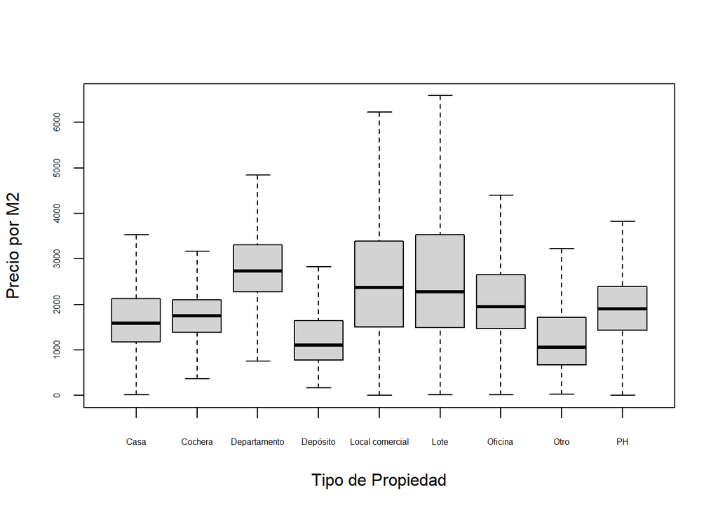

```r
boxplot(precio_m2 ~ property_type, datos, pch=18,las=0, outline=FALSE, cex.axis=0.5, xlab = "Tipo de Propiedad", ylab="Precio por M2")
```

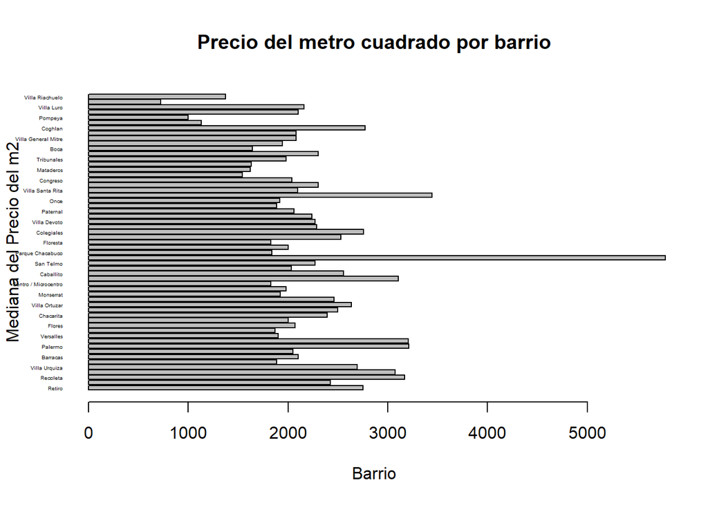

```r
barrios <- unique(datos$l3)
barrios <- barrios[!is.na(barrios)]
mediana_por_barrio <- c()
for (barrio in barrios)
  {
  mediana_por_barrio <- c(mediana_por_barrio,
                          median(datos$precio_m2[datos$l3==barrio], na.rm = T))
}

barplot(mediana_por_barrio, names.arg = barrios, cex.names = 0.3, main="Precio del metro cuadrado por barrio", xlab = "Barrio" , ylab="Mediana del Precio del m2", horiz = TRUE, las=1)
```

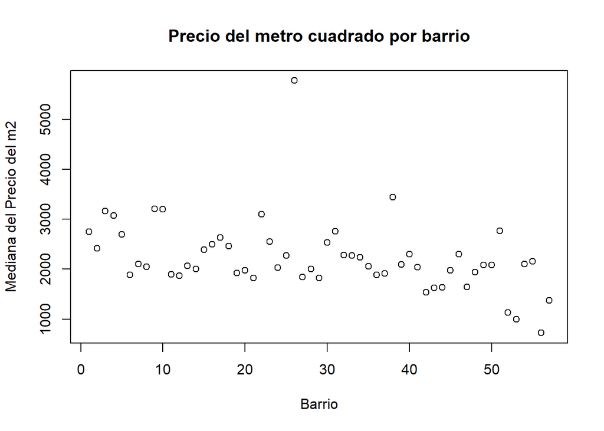

```r
plot(mediana_por_barrio, main="Precio del metro cuadrado por barrio", xlab = "Barrio" , ylab="Mediana del Precio del m2", type="p")
```

Se puede ver por los gráficos que el dataset varía en su precio debido al barrio como al tipo de propiedad.

#¿Cuales propiedades son caras, promedio o baratas? Construya una partición que separe el precio por metro cuadrado en tres categorías.

```r
particiones <- quantile(datos$precio_m2, probs = c(0.33, 0.66), na.rm = TRUE)
particiones
```

```
##      33%      66%
## 2198.067 2919.355
```

Las propiedades baratas son aquellas que valen menos de 2198 usd el metro cuadrado. Las promedio son las que van desde 2198 a 2919 y luego, las caras son las que valen m[as de 2919 usd el m2.

#¿Cómo cambia el precio por cantidad de habitaciones (rooms) en el dataset? ¿Cambia al considerar distintos tipos de propiedad?¿Y distintos barrios?

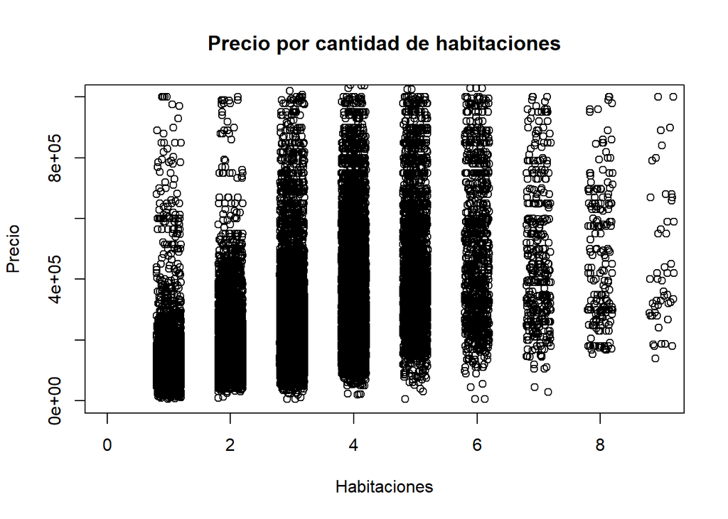

```r
plot(jitter(datos$rooms), datos$price, main="Precio por cantidad de habitaciones", xlab="Habitaciones", ylab = "Precio", ylim=c(0,1000000), xlim = c(0,9))
```

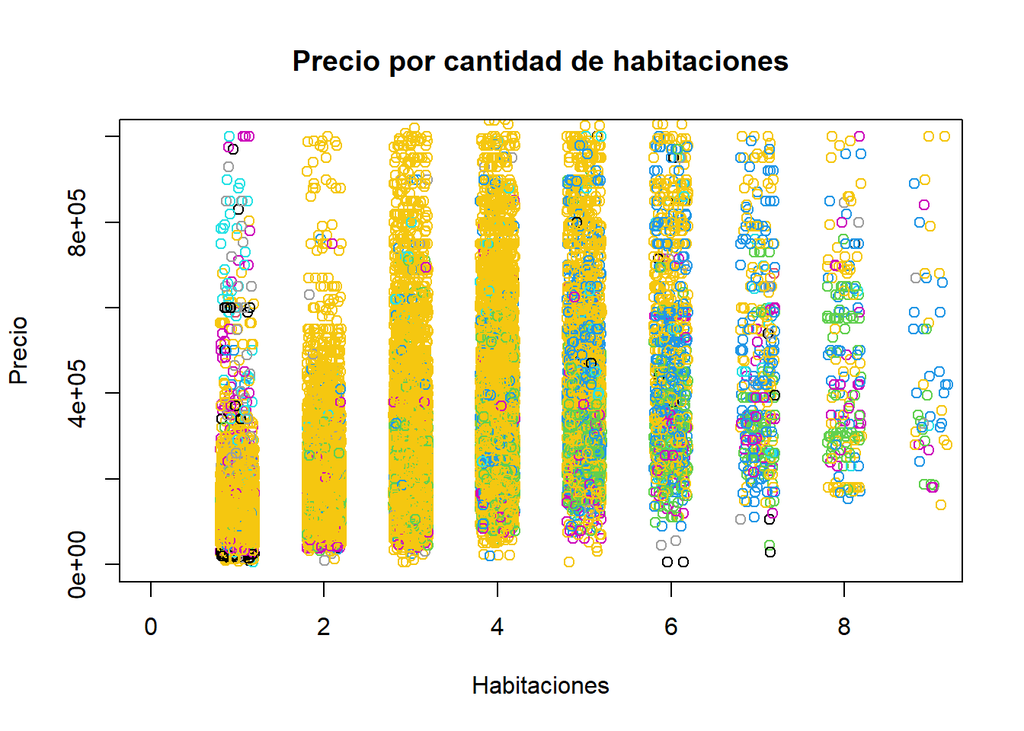

```r
datos$property_type <- factor(datos$property_type, levels = unique(datos$property_type), labels = unique(datos$property_type))
plot(jitter(datos$rooms), datos$price, main="Precio por cantidad de habitaciones", xlab="Habitaciones", ylab = "Precio", ylim=c(0,1000000), xlim = c(0,9), col=datos$property_type)
```

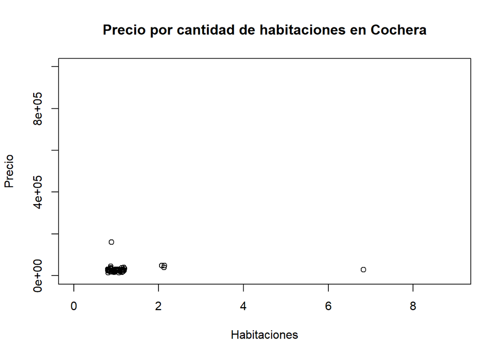

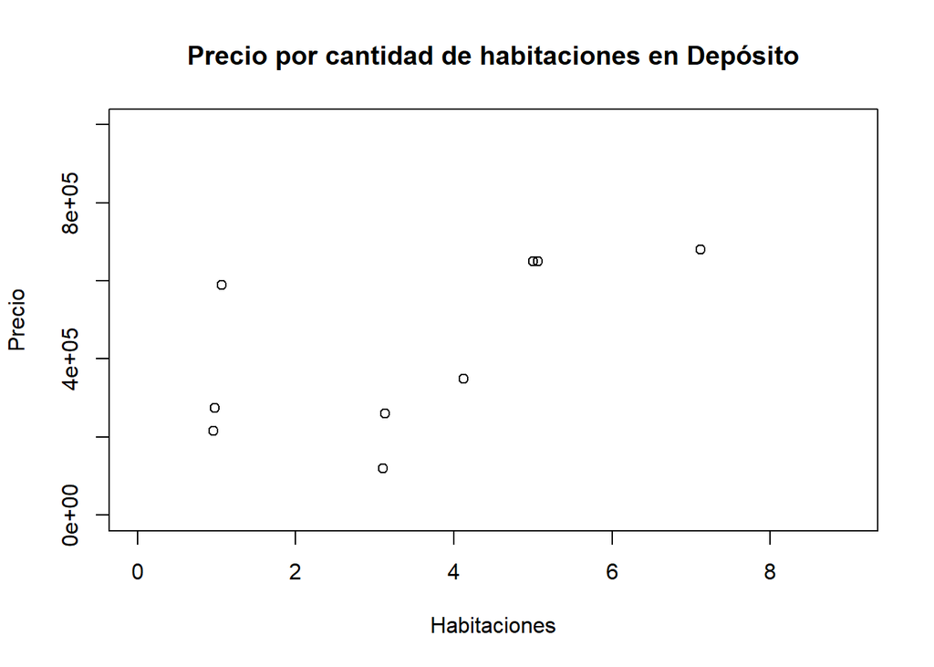

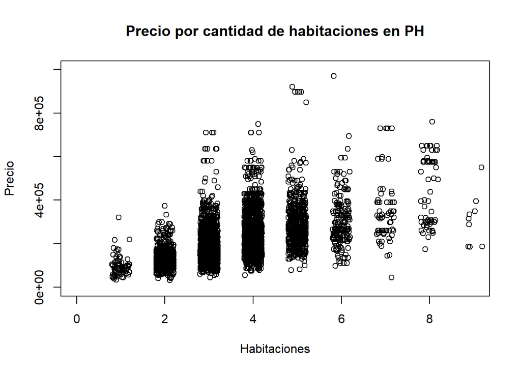

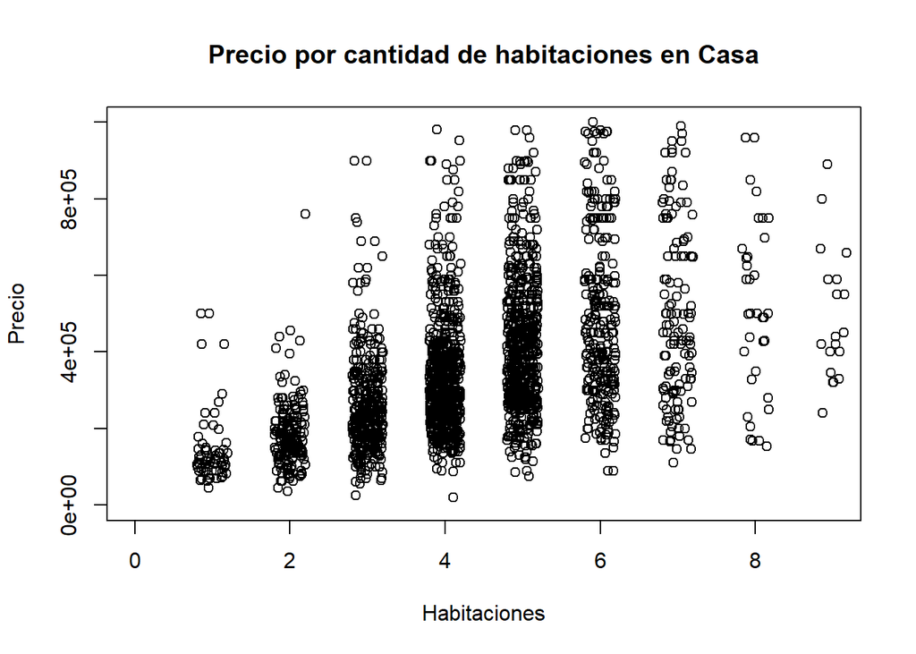

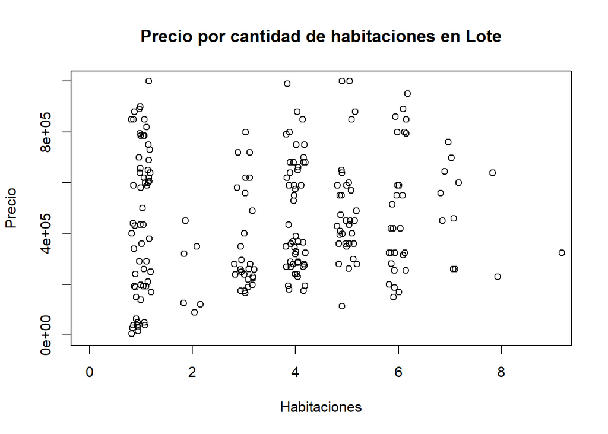

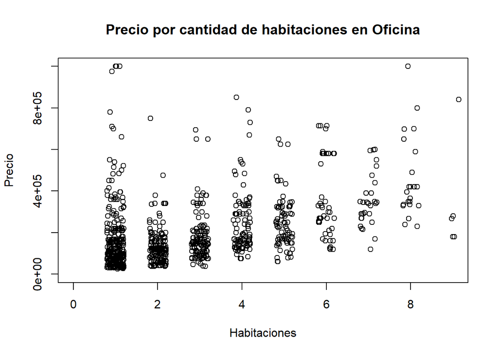

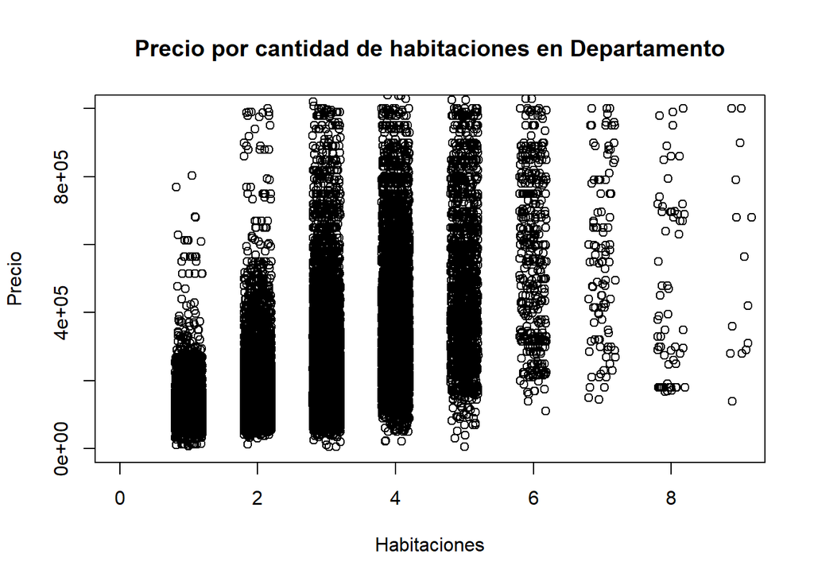

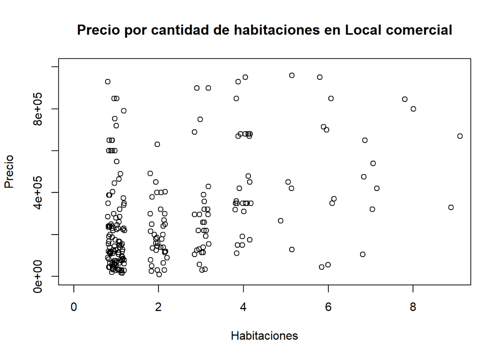

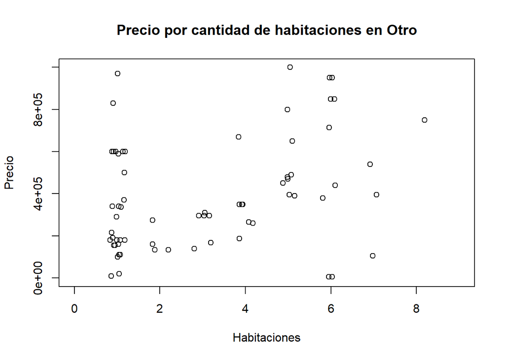

```r
tipos <- unique(datos$property_type)

for(tipo in tipos){
  plot(jitter(datos$rooms[datos$property_type==tipo]), datos$price[datos$property_type==tipo], main=paste("Precio por cantidad de habitaciones en",tipo), xlab="Habitaciones", ylab = "Precio", ylim=c(0,1000000), xlim = c(0,9))
}
```

El precio varía en función de las habitaciones para algunos tipos de propiedad: PH, casas y departamentos.

En el resto de los tipos de propiedad esto no pareciera ser un factor determinante.

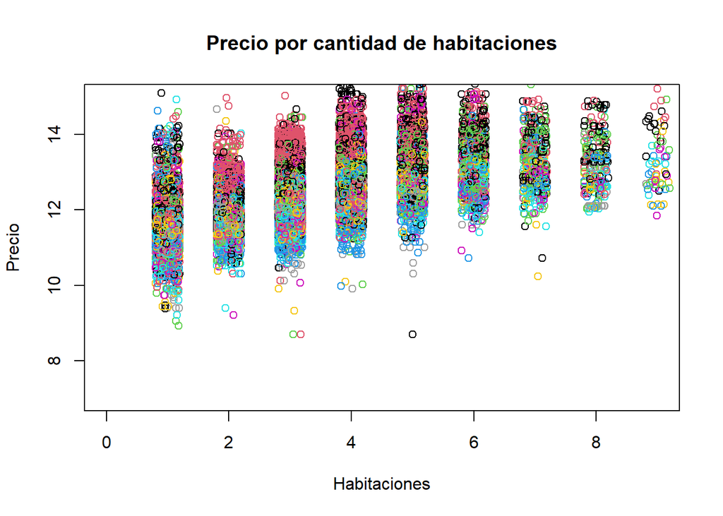

```r
datos$l3 <- factor(datos$l3, levels = barrios, labels = barrios)
plot(jitter(datos$rooms), log(datos$price), main="Precio por cantidad de habitaciones", xlab="Habitaciones", ylab = "Precio", ylim=c(7,15), xlim = c(0,9), col=datos$l3)
```

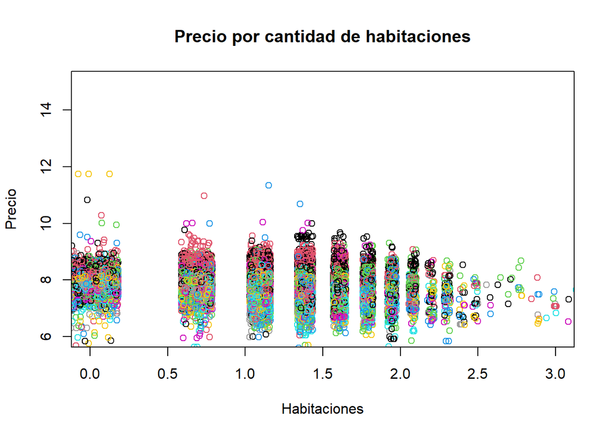

```r
plot(log(jitter(datos$rooms)), log(datos$precio_m2), main="Precio por cantidad de habitaciones", xlab="Habitaciones", ylab = "Precio", ylim=c(6,15), xlim = c(0,3), col=datos$l3)
```

#¿Qué considera que describe mejor el precio de una propiedad, su número de habitaciones (rooms) o su superficie cubierta?